# Pareto Served-Rate Scenarios: Summary of Current Findings

Patient Behavior Factorial Scheduling Simulation

```
Using data from: C:\Users\yangy\OneDrive - University of Toronto\Desktop\Xin\Columbia\CBS Yob\Git Clone\CUIMC-Appointment-Simulation\outputs\pareto_presentation
Repository root: C:\Users\yangy\OneDrive - University of Toronto\Desktop\Xin\Columbia\CBS Yob\Git Clone\CUIMC-Appointment-Simulation
Figures will be saved to: C:\Users\yangy\OneDrive - University of Toronto\Desktop\Xin\Columbia\CBS Yob\Git Clone\CUIMC-Appointment-Simulation\figures

Setup complete.
Validated meaningful-Pareto cells: 212
```

|  | Policy | validated_cells | validated_backgrounds |
| --- | --- | --- | --- |
| 0 | Horizon only | 73 | 43 |
| 1 | Reservation only | 0 | 0 |
| 2 | Both flexible | 139 | 33 |

# 1 Executive summary

- **Reservation-only:** no independently validated meaningful-Pareto scenario was found.
- **Both-flexible:** 33 validated Pareto backgrounds were found.
- Every validated both-flexible cell used a very short **2–4 day booking horizon**.
- **Main mechanism:**
  - short horizon creates the underlying served-rate improvement;
  - reservation then reallocates some of that gain toward Class 1.
- The strongest conditions associated with Pareto outcomes are:
  - intermediate congestion;
  - higher no-show sensitivity;
  - higher capacity for reservation-involved policies.
- Validated Pareto scenarios generally also improve utilization relative to baseline.
- However, this is **not yet** a matched comparison against the utilization-optimal policy for the exact same background.

# 2 1. When do reservation-involved policies produce Pareto improvements?

## 2.1 Independent validation results

|  | Policy | Discovery candidates | Validated cells | Validated backgrounds |
| --- | --- | --- | --- | --- |
| 0 | Both flexible | 1452 | 139 | 33 |
| 1 | Horizon only | 253 | 73 | 43 |
| 2 | Reservation only | 63 | 0 | 0 |

- **Reservation-only**
  - 63 discovery candidates.
  - **0 validated cells.**
  - **0 validated backgrounds.**
- **Both-flexible**
  - 1,452 discovery candidates.
  - **139 validated cells.**
  - **33 validated backgrounds.**
- **Horizon-only**
  - 253 discovery candidates.
  - **73 validated cells.**
  - **43 validated backgrounds.**
- Interpretation:
  - no reservation-only candidate survived the independent validation step;
  - this does **not** mathematically prove that a reservation-only Pareto policy can never exist;
  - it means none was reliably detected in the current experiment.

## 2.2 What role does reservation play inside both-flexible?

|  | Comparison | Cells examined | Reservation increment itself Pareto |
| --- | --- | --- | --- |
| 0 | Reservation increment vs same horizon | 139 | 0 |

- Among the validated both-flexible cells, the **reservation increment itself was never Pareto-improving** relative to the same horizon without reservation.
- The observed mechanism is:

$$\text{short horizon}
\rightarrow
\text{served-rate gain for both classes}
\rightarrow
\text{reservation shifts part of the gain toward Class 1}.$$

- Reservation can remain part of a final Pareto policy when:
  - the short horizon first creates a positive Class 2 buffer;
  - reservation increases Class 1 access;
  - Class 2 gives up part of its gain;
  - Class 2 nevertheless remains at or above its no-policy baseline.

## 2.3 Example: special low-demand case

|  | Component | Class 1 change (pp) | Class 2 change (pp) |
| --- | --- | --- | --- |
| 0 | Horizon vs baseline | 0.390 | 0.322 |
| 1 | Reservation increment | 1.592 | -0.272 |
| 2 | Final both-flexible vs baseline | 1.982 | 0.050 |

- Clinic context:
  - $\rho=1.2$
  - Class 1 share = 10%
  - capacity = 50 slots/day
- Approximate decomposition:
  - Horizon component:
    - Class 1: **+0.39 pp**
    - Class 2: **+0.32 pp**
  - Reservation increment:
    - Class 1: **+1.59 pp**
    - Class 2: **−0.27 pp**
  - Final both-flexible policy:
    - still Pareto because Class 2 remains slightly above baseline.

## 2.4 Demand conditions

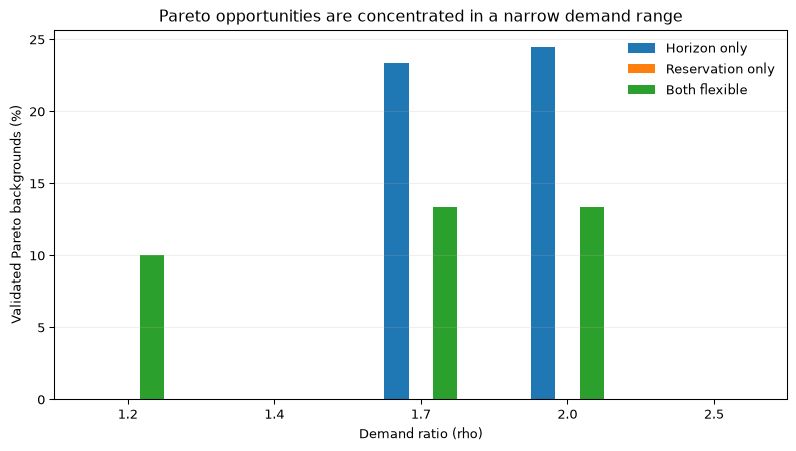

- Main Pareto region:
  - **$\rho=1.7$**
  - **$\rho=2.0$**
- Both-flexible also has a distinct cluster at:
  - **$\rho=1.2$**
- No validated Pareto backgrounds were detected at:
  - $\rho=1.4$
  - $\rho=2.5$

# 3 2. How does horizon length change when optimizing for Pareto served rate?

## 3.1 Validated Pareto horizon settings

|  | Policy | Median H | H: 25th pct. | H: 75th pct. | Minimum H | Maximum H | Median Q | Median reservation window |
| --- | --- | --- | --- | --- | --- | --- | --- | --- |
| 0 | Horizon only | 3.0 | 3.0 | 4.0 | 2.0 | 5.0 | 0.0 | -1.0 |
| 2 | Both flexible | 3.0 | 2.0 | 4.0 | 2.0 | 4.0 | 10.0 | 3.0 |

- **Horizon-only Pareto**
  - median horizon = **3 days**
  - middle 50% = **3–4 days**
- **Both-flexible Pareto**
  - median horizon = **3 days**
  - middle 50% = **2–4 days**
  - full validated range = **2–4 days**
- Therefore, all validated both-flexible Pareto results rely on an extremely short booking horizon.

## 3.2 Comparison with utilization optimization

|  | Policy | Low no-show | Medium no-show | High no-show |
| --- | --- | --- | --- | --- |
| 0 | Horizon only | 3.99 | 3.06 | 2.98 |
| 1 | Both flexible | 6.85 | 5.95 | 5.84 |

- Under the previous utilization optimization:
  - **Horizon-only**
    - low no-show: 3.99 days
    - medium no-show: 3.06 days
    - high no-show: 2.98 days
  - **Both-flexible**
    - low no-show: 6.85 days
    - medium no-show: 5.95 days
    - high no-show: 5.84 days
- Main comparison:
  - **Horizon-only**
    - Pareto and utilization optimization both favor a horizon around 3–4 days.
  - **Both-flexible**
    - utilization optimization favored roughly a **6-day horizon**;
    - validated Pareto cases use only **2–4 days**.

> **Operational caveat:** a 2–4 day booking horizon may be unrealistic or undesirable in real clinic operations. This is therefore an important limitation of the current both-flexible Pareto results.

# 4 3. Top five trends in the Pareto scenarios

## 4.1 Trend 1 — Pareto opportunities cluster under intermediate congestion

|  | Policy | rho | pareto_backgrounds | backgrounds | Pareto rate (%) |
| --- | --- | --- | --- | --- | --- |
| 0 | Horizon only | 1.2 | 0 | 90 | 0.0 |
| 1 | Horizon only | 1.4 | 0 | 90 | 0.0 |
| 2 | Horizon only | 1.7 | 21 | 90 | 23.3 |
| 3 | Horizon only | 2.0 | 22 | 90 | 24.4 |
| 4 | Horizon only | 2.5 | 0 | 90 | 0.0 |
| 10 | Both flexible | 1.2 | 9 | 90 | 10.0 |
| 11 | Both flexible | 1.4 | 0 | 90 | 0.0 |
| 12 | Both flexible | 1.7 | 12 | 90 | 13.3 |
| 13 | Both flexible | 2.0 | 12 | 90 | 13.3 |
| 14 | Both flexible | 2.5 | 0 | 90 | 0.0 |

- Horizon-only:
  - $\rho=1.7$: **23.3%**
  - $\rho=2.0$: **24.4%**
- Both-flexible:
  - $\rho=1.7$: **13.3%**
  - $\rho=2.0$: **13.3%**
- Interpretation:
  - policy must matter enough to change realized service;
  - but excessive congestion may leave too little slack for both classes to improve simultaneously.

## 4.2 Trend 2 — No-show sensitivity matters much more than balking sensitivity

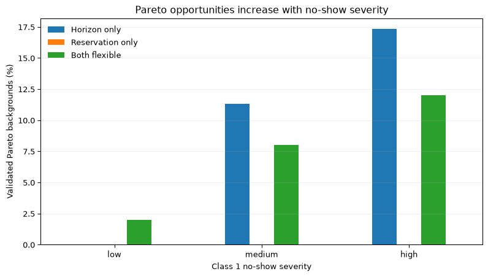

- Horizon-only:
  - low no-show: **0%**
  - medium: **11.3%**
  - high: **17.3%**
- Both-flexible:
  - low: **2.0%**
  - medium: **8.0%**
  - high: **12.0%**

### 4.2.1 Balking comparison

|  | Policy | balk_level | Pareto rate (%) |
| --- | --- | --- | --- |
| 0 | Horizon only | low | 8.7 |
| 1 | Horizon only | medium | 10.0 |
| 2 | Horizon only | high | 10.0 |
| 6 | Both flexible | low | 8.7 |
| 7 | Both flexible | medium | 6.0 |
| 8 | Both flexible | high | 7.3 |

- Balking does not show the same clear monotonic relationship.
- Main conclusion:
  - **delay-sensitive no-show risk is the stronger behavioral predictor of Pareto opportunities.**

## 4.3 Trend 3 — Horizon generates the underlying gain; reservation is mainly distributional

- Reservation-only:
  - **0 validated Pareto backgrounds**
- Both-flexible:
  - **33 validated Pareto backgrounds**
- But:
  - reservation itself was Pareto in **0 of 139** matched both-flexible cells.
- Interpretation:

$$\text{horizon compression}
\rightarrow
\text{system-level served-rate gain}$$

followed by:

$$\text{reservation}
\rightarrow
\text{more of that gain directed toward Class 1}.$$

- This is an important distinction:
  - the current evidence does **not** show that reservation alone creates a joint served-rate improvement.

## 4.4 Trend 4 — Pareto gains are asymmetric toward Class 1

|  | Policy | Median Class 1 gain (pp) | Median Class 2 gain (pp) |
| --- | --- | --- | --- |
| 0 | Horizon only | 1.54 | 0.12 |
| 2 | Both flexible | 1.08 | 0.12 |

- Both-flexible:
  - Class 1: **+1.08 pp**
  - Class 2: **+0.12 pp**
- Horizon-only:
  - Class 1: **+1.54 pp**
  - Class 2: **+0.12 pp**
- Typical Pareto structure:

$$\text{large Class 1 improvement}
+
\text{small positive Class 2 cushion}.$$

- These are generally **not equal gains** for both patient classes.

## 4.5 Trend 5 — Higher capacity is especially favorable for both-flexible Pareto outcomes

|  | Policy | slots_per_day | pareto_backgrounds | backgrounds | Pareto rate (%) |
| --- | --- | --- | --- | --- | --- |
| 0 | Horizon only | 30 | 23 | 225 | 10.2 |
| 1 | Horizon only | 50 | 20 | 225 | 8.9 |
| 4 | Both flexible | 30 | 8 | 225 | 3.6 |
| 5 | Both flexible | 50 | 25 | 225 | 11.1 |

- Both-flexible:
  - 30 slots/day: **3.6%**
  - 50 slots/day: **11.1%**
- Horizon-only:
  - 30 slots/day: **10.2%**
  - 50 slots/day: **8.9%**
- Interpretation:
  - additional capacity appears especially useful when reservation is part of the policy;
  - with more slots, it may be easier to protect Class 1 capacity without materially reducing Class 2 access.

## 4.6 Secondary pattern — Class 1 share is non-monotonic

|  | Class 1 share | pareto_backgrounds | backgrounds | Pareto rate (%) |
| --- | --- | --- | --- | --- |
| 10 | 0.1 | 9 | 90 | 10.0 |
| 11 | 0.3 | 5 | 90 | 5.6 |
| 12 | 0.5 | 4 | 90 | 4.4 |
| 13 | 0.7 | 4 | 90 | 4.4 |
| 14 | 0.9 | 11 | 90 | 12.2 |

- Both-flexible Pareto rate:
  - Class 1 share 10%: **10.0%**
  - 30%: **5.6%**
  - 50%: **4.4%**
  - 70%: **4.4%**
  - 90%: **12.2%**
- “Non-monotonic” means:
  - the Pareto rate does not continuously rise as Class 1 share rises;
  - it also does not continuously fall.
- Instead, the rates are higher at both extremes and lower in the middle.
- This should **not** be interpreted as:
  - “extreme Class 1 shares are always better.”
- The 10% and 90% cases occur under different clinic conditions and likely reflect different mechanisms.

# 5 4. What happens to utilization in the Pareto scenarios?

## 5.1 Utilization relative to baseline

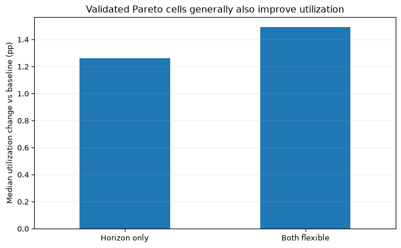

- Horizon-only validated Pareto cells:
  - median utilization change = approximately **+1.26 pp**
- Both-flexible validated Pareto cells:
  - median utilization change = approximately **+1.49 pp**
- This is encouraging:
  - the Pareto served-rate scenarios generally do **not** require sacrificing utilization relative to the no-policy baseline.

## 5.2 Utilization by clinic context

|  | Policy | rho | class1_share | slots_per_day | validated_backgrounds | Median utilization change (pp) |
| --- | --- | --- | --- | --- | --- | --- |
| 0 | Both flexible | 1.2 | 0.1 | 50 | 9 | -0.01 |
| 1 | Both flexible | 1.7 | 0.3 | 50 | 3 | 0.46 |
| 2 | Both flexible | 1.7 | 0.9 | 30 | 6 | 1.48 |
| 3 | Both flexible | 1.7 | 0.9 | 50 | 3 | 1.40 |
| 4 | Both flexible | 2.0 | 0.3 | 50 | 2 | 1.87 |
| 5 | Both flexible | 2.0 | 0.5 | 50 | 4 | 3.04 |
| 6 | Both flexible | 2.0 | 0.7 | 50 | 4 | 4.29 |
| 7 | Both flexible | 2.0 | 0.9 | 30 | 2 | 5.15 |
| 8 | Horizon only | 1.7 | 0.1 | 30 | 6 | 0.30 |
| 9 | Horizon only | 1.7 | 0.3 | 30 | 3 | 0.50 |
| 10 | Horizon only | 1.7 | 0.3 | 50 | 3 | 0.45 |
| 11 | Horizon only | 1.7 | 0.9 | 30 | 6 | 1.48 |
| 12 | Horizon only | 1.7 | 0.9 | 50 | 3 | 1.40 |
| 13 | Horizon only | 2.0 | 0.1 | 30 | 2 | 0.58 |
| 14 | Horizon only | 2.0 | 0.1 | 50 | 4 | 0.54 |
| 15 | Horizon only | 2.0 | 0.3 | 30 | 4 | 1.28 |
| 16 | Horizon only | 2.0 | 0.3 | 50 | 2 | 1.87 |
| 17 | Horizon only | 2.0 | 0.5 | 50 | 4 | 3.04 |
| 18 | Horizon only | 2.0 | 0.7 | 50 | 4 | 4.29 |
| 19 | Horizon only | 2.0 | 0.9 | 30 | 2 | 5.15 |

- At $\rho=2.0$, several both-flexible contexts have median utilization gains of roughly:
  - **+1.9 pp**
  - up to approximately **+5.1 pp**
- Important exception:
  - $\rho=1.2$
  - Class 1 share = 10%
  - capacity = 50
- In that case:
  - the policy is Pareto in served rate;
  - utilization is essentially unchanged.

## 5.3 Comparison with utilization optimization

The utilization numbers above measure:

$$U_{\text{Pareto policy}}
-
U_{\text{baseline}}.$$

They do **not** measure:

$$U_{\text{Pareto policy}}
-
U_{\text{utilization-optimal policy}}.$$

Therefore:

- it is correct to say:
  - **Pareto policies generally also improve utilization relative to baseline**;
- it is **not** yet correct to say:
  - Pareto optimization produces greater utilization than utilization optimization.

The matched quantity needed for that comparison is:

$$U_{\text{utilization-optimal}}
-
U_{\text{Pareto policy}}.$$

That quantity has not yet been summarized in the current presentation dataset.

# 6 Bottom line

- **Reservation-only produced no independently validated meaningful-Pareto scenario.**
- **Both-flexible produced validated Pareto outcomes, but all relied on very short 2–4 day horizons.**
- The main mechanism appears to be:

$$\text{short horizon creates the gain}
\rightarrow
\text{reservation reallocates it toward Class 1}.$$

- The five main trends are:
  1. **Intermediate congestion** is the main Pareto region.
  2. **No-show sensitivity** matters substantially more than balking sensitivity.
  3. Horizon shortening creates the underlying system-level gain; reservation is mainly **distributional**.
  4. Pareto gains are strongly **asymmetric toward Class 1**.
  5. **Higher capacity** is particularly favorable for reservation-involved Pareto outcomes.
- Validated Pareto scenarios also generally have **positive utilization changes relative to baseline**.
- The main practical limitation is the very short booking horizon required by the current both-flexible Pareto cases.

# 7 What does “independently validated” mean?

- Candidate policies were first identified using simulation seeds:

$$1000,\ldots,1004.$$

- The promising policies were then rerun using fresh seeds:

$$2000,\ldots,2019.$$

- The clinic scenario remains fixed across those seeds:
  - demand level $\rho$;
  - Class 1 share;
  - slots per day;
  - behavior probabilities;
  - behavior thresholds;
  - booking horizon;
  - reservation quantity;
  - reservation window.
- What changes across seeds is the random realization of:
  - daily arrivals;
  - within-day patient ordering;
  - individual balking;
  - cancellations;
  - no-shows.
- Independent validation therefore asks:

> Does the apparent Pareto result persist when we simulate new random patient-flow histories under the exact same clinic and policy conditions?